# TSA passenger screening data as of July 18

The US Transportation Security Administration began publishing daily screening volumes at US airports in the spring of 2020, as global efforts to limit the spread of the Covid-19 pandemic smothered air travel demand. The administration has continued to publish daily data giving valuable insight into both US air travel’s collapse and ongoing recovery.

### Latest screening data

| Year | Average |
| --- | --- |
| 2022 | 2,252,277 |
| 2021 | 2,034,054 |
| 2020 | 673,483 |
| 2019 | 2,568,980 |

TSA reported 2,350,360 passengers screened on the most recent day with data. That represents 89pc of 2019 screenings for the same day. Refiners and air carriers estimated that 85pc of 2019 demand represents full domestic capacity. The remaining 15pc of international demand was presumed more vulnerable to trickier global considerations on Covid-19 mitigation policies.

The table on the right looks at how average screenings stack up in available data for the the month of July so far.

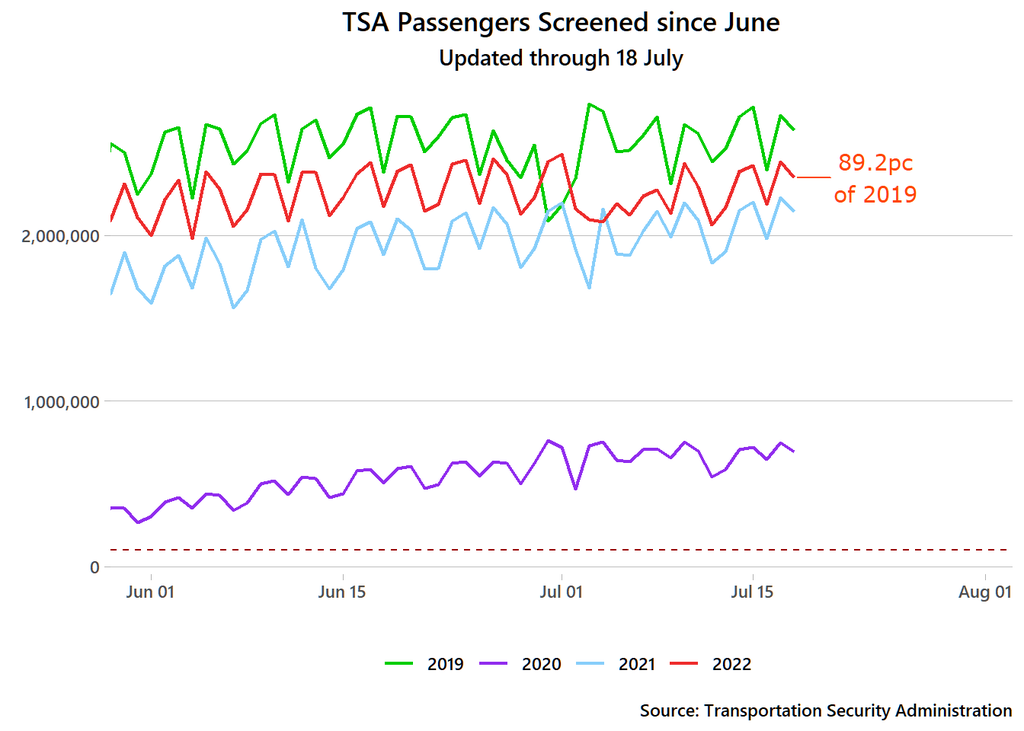

### Week-to-week comparisons

Air travel varies significantly based on the day of the week. These plots look at the change in screened passengers from seven days earlier, isolating for these comparisons.

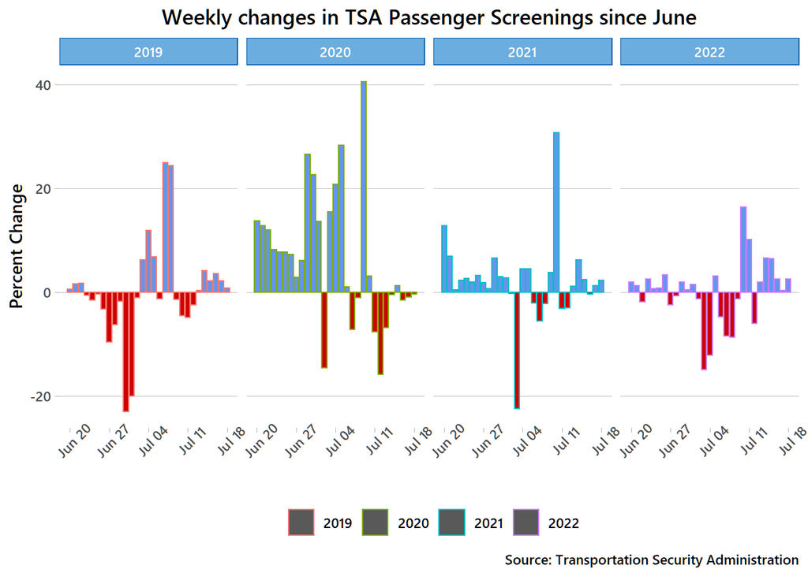

Screenings collapsed to 100,000 in April 2020 as governments worldwide restricted travel. Air travel began a sustained recovery in the first quarter of 2021, but has continued to lag pre-pandemic levels. Reduced business trips, more difficult international travel and other factors continue to limit the recovery of US passenger screenings.

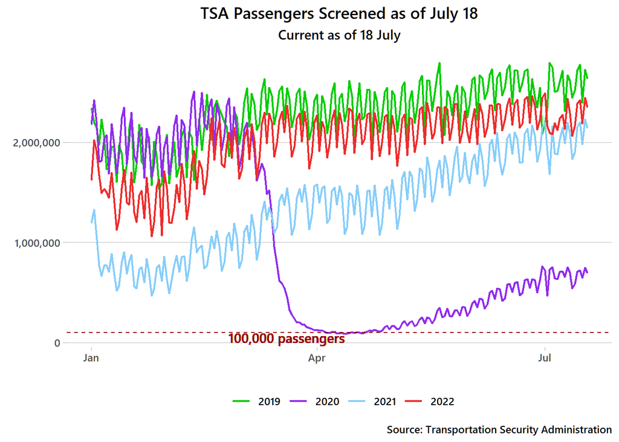